# permutation_entropy

permutation_entropy: calculate the permutation entropy.

permutation_entropy(x, tau, dimension)

x: 1차원 time series 벡터 값

tau: xt 값 간의 시간 간격을 결정하는 embedded 시간 지연 스칼라 값

dimension: 임베딩할 차원

```python
def permutation_entropy(x, tau, dimension):
    """
    Calculate the permutation entropy.

    Three steps are needed for this:

    1. chunk the data into sub-windows of length D starting every tau.
       Following the example from the reference, a vector

        x = [4, 7, 9, 10, 6, 11, 3

       with D = 3 and tau = 1 is turned into

           [[ 4,  7,  9],
            [ 7,  9, 10],
            [ 9, 10,  6],
            [10,  6, 11],
            [ 6, 11,  3]]

    2. replace each D-window by the permutation, that
       captures the ordinal ranking of the data.
       That gives

           [[0, 1, 2],
            [0, 1, 2],
            [1, 2, 0],
            [1, 0, 2],
            [1, 2, 0]]

    3. Now we just need to count the frequencies of every permutation
       and return their entropy (we use log_e and not log_2).

    Ref: https://www.aptech.com/blog/permutation-entropy/
         Bandt, Christoph and Bernd Pompe.
         “Permutation entropy: a natural complexity measure for time series.”
         Physical review letters 88 17 (2002): 174102 .
    """

    X = _into_subchunks(x, dimension, tau)
    if len(X) == 0:
        return np.nan
    # Now that is clearly black, magic, but see here:
    # https://stackoverflow.com/questions/54459554/numpy-find-index-in-sorted-array-in-an-efficient-way
    permutations = np.argsort(np.argsort(X))
    # Count the number of occurences
    _, counts = np.unique(permutations, axis=0, return_counts=True)
    # turn them into frequencies
    probs = counts / len(permutations)
    # and return their entropy
    return -np.sum(probs * np.log(probs))
```

Install tsfresh, load the data

```python
pip install tsfresh
```

# Feature Extraction and Selection

시계열 데이터에서 tsfresh가 어떻게 특징값을 추출하고 사용하는지를 로봇 실행 실패 데이터 셋을 사용해서 학습

```python
%matplotlib inline

import numpy as np
import matplotlib.pylab as plt

from tsfresh import extract_features, extract_relevant_features, select_features
from tsfresh.utilities.dataframe_functions import impute
from tsfresh.feature_extraction import ComprehensiveFCParameters

from sklearn.tree import DecisionTreeClassifier
from sklearn.model_selection import train_test_split
from sklearn.metrics import classification_report
```

# Load and visualize data

about dataset: 88가지 종류의 로봇(id = 1~88)이 실행을 성공했을 때(y=True), 실패했을 때(y=False) 각 실행마다 15개(행)의 힘(F) 및 토크(T) 샘플이 제공된다.

x,y,z축에 대해 일정한 시간 간격으로 측정되었다.

y: 로봇 실행이 성공했는지, 실패했는지가 True, False로 구분되며 총 88개

df(x):

데이터 프레임의 각 행

id: 실행 횟수(1~88번)

time: 각 실행당 0~14

F_x, F_y, F_z, T_x, T_y, T_z: 각 실행했을 때 힘(F) 및 토크(T) 센서 값

```python
# 데이터 다운로드
from tsfresh.examples import robot_execution_failures

robot_execution_failures.download_robot_execution_failures()
df, y = robot_execution_failures.load_robot_execution_failures()
display(df.head())
print(np.shape(df))
```

|  | id | time | F_x | F_y | F_z | T_x | T_y | T_z |
| --- | --- | --- | --- | --- | --- | --- | --- | --- |
| 0 | 1 | 0 | -1 | -1 | 63 | -3 | -1 | 0 |
| 1 | 1 | 1 | 0 | 0 | 62 | -3 | -1 | 0 |
| 2 | 1 | 2 | -1 | -1 | 61 | -3 | 0 | 0 |
| 3 | 1 | 3 | -1 | -1 | 63 | -2 | -1 | 0 |
| 4 | 1 | 4 | -1 | -1 | 63 | -3 | -1 | 0 |

```
(1320, 8)
```

```python
y
```

```
1      True
2      True
3      True
4      True
5      True
      ...
84    False
85    False
86    False
87    False
88    False
Length: 88, dtype: bool
```

```python
print(y.shape)
print(type(y))
```

```
(88,)
<class 'pandas.core.series.Series'>
```

로봇 실행을 성공했을 때와 실패했을 때의 센서값을 그려서 차이가 있는지 직접 눈으로 확인

성공했을 때는 F_z값이 60 근처에서, 나머지 값들은 0 근처에 있는 것을 확인할 수 있음

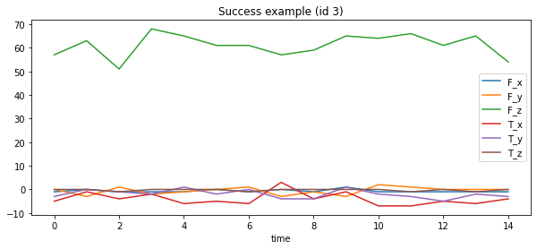

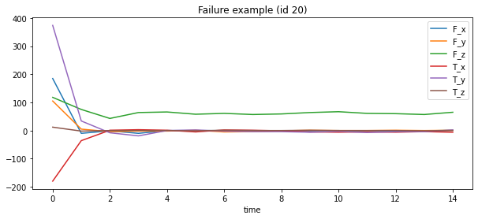

```python
df[df.id == 3][['time', 'F_x', 'F_y', 'F_z', 'T_x', 'T_y', 'T_z']].plot(x='time', title='Success example (id 3)', figsize=(10, 4));
df[df.id == 20][['time', 'F_x', 'F_y', 'F_z', 'T_x', 'T_y', 'T_z']].plot(x='time', title='Failure example (id 20)', figsize=(10, 4));
```